# **Traffic Patterns Based on Property in Maryland**

# Machine Learning Models (Linear Regression):

```python
from sklearn.preprocessing import MinMaxScaler


df3 = df3[['X','Y','NFMTTLVL']]
# Two standard deviations are offset
offset = 2 * df3['NFMTTLVL'].std()
df3 = df3[(df3['NFMTTLVL'] < offset + df3['NFMTTLVL'].mean()) & (df3['NFMTTLVL'] > df3['NFMTTLVL'].mean() - offset) ]
scale = MinMaxScaler()
df3['NFMTTLVL'] = scale.fit_transform(df3['NFMTTLVL'].values.reshape(-1,1))
df3.describe()
```

|  | X | Y | NFMTTLVL |
| --- | --- | --- | --- |
| count | 1.136374e+06 | 1.136374e+06 | 1.136374e+06 |
| mean | -8.548267e+06 | 4.737460e+06 | 3.418464e-01 |
| std | 6.959490e+04 | 5.400215e+04 | 1.773999e-01 |
| min | -8.848425e+06 | 4.570409e+06 | 0.000000e+00 |
| 25% | -8.574883e+06 | 4.710824e+06 | 2.155632e-01 |
| 50% | -8.547916e+06 | 4.741854e+06 | 3.118921e-01 |
| 75% | -8.517774e+06 | 4.778381e+06 | 4.367744e-01 |
| max | -8.354580e+06 | 4.825755e+06 | 1.000000e+00 |

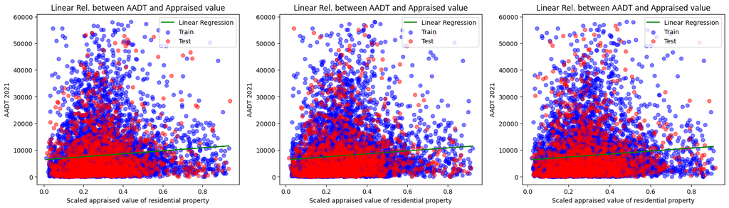

```python
import numpy as np
from sklearn.model_selection import train_test_split
from sklearn.linear_model import LinearRegression
from sklearn.metrics import mean_squared_error

index = 0
MSE = []
# Create the subplots
fig, axes = plt.subplots(1, 3, figsize=(20, 5))
# Begin to construct the Linear Regression models and their errors based on how many neighbors are used to construct it
for idx in [20, 50, 100]:
  X = []
  # test3 is a sanitized version of df1 with all the outliers removed.
  ext_pts = test3[['x','y']]
  ext_pts = ext_pts.rename(columns = {"y":"Y", "x": "X"})
  ext_pts['NFMTTLVL'] = (df3['NFMTTLVL'].mean())
  knn = NearestNeighbors(n_neighbors=idx, algorithm='ball_tree').fit(df3)
  not_needed, indices = knn.kneighbors(ext_pts)
  for x in indices:
    z1 = 0
    idxx = 0
    for e1 in x:
      z1 = z1 + df3.iloc[e1][2]
      idxx = idxx + 1
    X.append(z1/idxx)
  Y = test3['AADT 2021']
  # Now we apply Linear regression by first splitting test and training data.
  X = np.array(X).reshape(-1,1)
  X_train, X_test, Y_train, Y_test = train_test_split(X,Y,test_size = 0.2)
  # Now train the model and test it through prediction
  model = (LinearRegression()).fit(X_train, Y_train)
  pred = model.predict(X_test)
  MSE.append(mean_squared_error(Y_test, pred))
  axes[index].plot(X_train, model.predict(X_train), color='green', label='Linear Regression')
  # Plot the linear dataset
  axes[index].scatter(X_train, Y_train, color='blue', label='Train', alpha=0.5)
  axes[index].scatter(X_test, Y_test, color='red', label='Test', alpha=0.5)
  axes[index].set_title('Linear Rel. between AADT and Appraised value')
  axes[index].set_xlabel('Scaled appraised value of residential property')
  axes[index].set_ylabel('AADT 2021')
  axes[index].legend()
  index = index + 1


plt.show()
```

Based on the plots above it's safe to assume that our model has failed to predict AADT based off of appraisal value alone with any of the number of selected neighbors 😞. However, the model does capture the slight positive linear relationship seen in the dataset. Also, notice how the data presented in this dataset is similar to the final graph of the data exploration section indicating that this model captures the same general trends observed.

```python
Nhbrs = [20, 50, 100]
idx = 0
for x in MSE:
  print("MSE of N = " + str(Nhbrs[idx]) + " is " + str(MSE[idx]))
  idx = idx + 1
```

```
MSE of N = 20 is 77570181.92464602
MSE of N = 50 is 84968274.97706568
MSE of N = 100 is 90865655.94216126
```

Let's just plot the same as above for K-Factor to see if there is a relationship with the appraised value as well. Just copied the code over due to time contraints(ideally this would be a function)

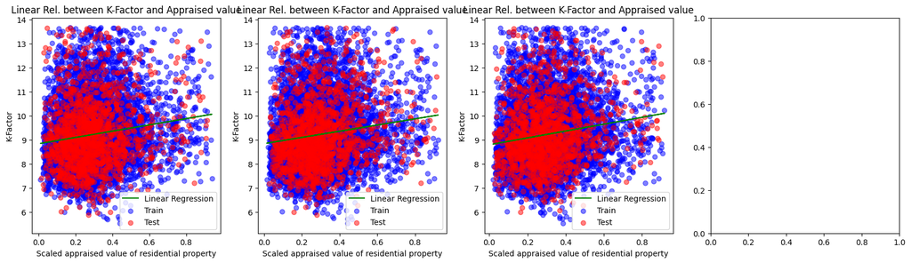

```python
index = 0
MSE2 = []
# Create the subplots
fig, axes = plt.subplots(1, 4, figsize=(20, 5))
# Begin to construct the Linear Regression models and their errors based on how many neighbors are used to construct it
for idx in [20, 50, 100]:
  X = []
  ext_pts = test3[['x','y']]
  ext_pts = ext_pts.rename(columns = {"y":"Y", "x": "X"})
  ext_pts['NFMTTLVL'] = (df3['NFMTTLVL'].mean())
  knn = NearestNeighbors(n_neighbors=idx, algorithm='ball_tree').fit(df3)
  not_needed, indices = knn.kneighbors(ext_pts)
  for x in indices:
    z1 = 0
    idxx = 0
    for e1 in x:
      z1 = z1 + df3.iloc[e1][2]
      idxx = idxx + 1
    X.append(z1/idxx)
  Y = test3['K-Factor']
  # Now we apply Linear regression by first splitting test and training data.
  X = np.array(X).reshape(-1,1)
  X_train, X_test, Y_train, Y_test = train_test_split(X,Y,test_size = 0.2)
  # Now train the model and test it through prediction
  model = (LinearRegression()).fit(X_train, Y_train)
  pred = model.predict(X_test)
  MSE2.append(mean_squared_error(Y_test, pred))
  axes[index].plot(X_train, model.predict(X_train), color='green', label='Linear Regression')
  # Plot the linear dataset
  axes[index].scatter(X_train, Y_train, color='blue', label='Train', alpha=0.5)
  axes[index].scatter(X_test, Y_test, color='red', label='Test', alpha=0.5)
  axes[index].set_title('Linear Rel. between K-Factor and Appraised value')
  axes[index].set_xlabel('Scaled appraised value of residential property')
  axes[index].set_ylabel('K-Factor')
  axes[index].legend()
  index = index + 1


plt.show()
```

By the graph shown we can conclude similarly as above that there is a weak positive linear relationship between the variables K-Factor and appraised value. However, for predicting K-Factor based on appraised value the model does not seem sufficent. *(Ignore the fourth graph)*

```python
# Listing the N=# of neighbors and their associated Mean Squared Error
Nhbrs = [20, 50, 100]
idx = 0
for x in MSE2:
  print("MSE of N = " + str(Nhbrs[idx]) + " is " + str(MSE2[idx]))
  idx = idx + 1
```

```
MSE of N = 20 is 1.931693600957757
MSE of N = 50 is 1.8626268591862483
MSE of N = 100 is 1.8432850340862257
```

Based on the Mean Squared Error being around 2 then it is safe to conclude that there is a weak positive linear relationship between appraised value and K-Factor. Since this model was applied over a large dataset it is safe to conclude that the model captures some general trend between the two variables and is not overfitted. Unlike AADT, the MSE error actually decreases for high N (number of neighbors).

# Conclusion:

Based on the results of the model, we can conclude that there is a slight positive linear relationship between both K-Factor and AADT with residential property values in the area. In other words, that implies that if you live in an area that is generally more expensive then your chances of experiencing peak traffic hours which are long and more traffic is marginally higher. Note, while there is correlation, it is not enough to prove causation and the both models in the machine learning section failed to predict accurately as the data has a more oval-spatial type appearance. Also, the model showed how the general trends observed with the zipocde data (second dataset) accurately depicted the general relationship between AADT and residential property values. This also leads us to speculate on wheter there is a real menaingful difference between the two metrics of residential property values, appraised value and residential prices (sold) since they had a similar structure with the exception being one utilized zipcodes as points for analysis and the other a large dataset with one million plus datapoints. This could be a topic of a potential discussion and analysis of each average individual property sale in comparison to appraised value of property in a given area.

The model created might be more accurate with more metrics/variables (such as the number of lanes at the road segment where traffic data was gathered) using gradient descent; however, the main purpose of this project was not to construct a model but rather detail the relationship between two factors which are rarely evaluated together. The residential pricing was interpolated onto the first dataset containing the traffic metric by utilizing unsupervised KNN. This carried some risks if the values of N=neighbors were not the right amount leading to potential overfitting if too small and underfitting if too small.

Furthermore, through exploratory analysis we found a pattern between the two traffic metrics, distinct characteristics of traffic-related data in this case the contribution percentage of AADT(Cars) to AADT(Total), and the broad linear relationship of traffic and residential prices which was confirmed in the machine learning section through regression on a large dataset which gives the observation credibility.

**For more information on the Libraries used and further analysis:**

Nearest Neighbors: https://scikit-learn.org/stable/modules/generated/sklearn.neighbors.NearestNeighbors.html#sklearn.neighbors.NearestNeighbors.kneighbors

For plotting graphs: https://seaborn.pydata.org/generated/seaborn.scatterplot.html

Using the iloc method: https://www.geeksforgeeks.org/python-extracting-rows-using-pandas-iloc/

For Linear Regression: https://scikit-learn.org/stable/modules/generated/sklearn.linear_model.LinearRegression.html